# Objective of the project:

## To distinguish between the diffenrent models of "Corgie" model vehicles.

## Importing required libraries.

```python
import numpy as np
from sklearn.linear_model import LinearRegression
import pandas as pd
import pandas_profiling
from scipy.stats import zscore
import matplotlib.pyplot as plt
%matplotlib inline
import warnings
warnings.filterwarnings('ignore')
import seaborn as sns
from sklearn import preprocessing
from sklearn.model_selection  import train_test_split
from sklearn.cluster import KMeans
from sklearn import model_selection
from scipy.stats import zscore
from sklearn.metrics import classification_report, confusion_matrix
from sklearn.svm import SVC
from sklearn import metrics
from sklearn.model_selection import KFold
from sklearn.model_selection import cross_val_score
from sklearn.linear_model import LinearRegression
from sklearn.decomposition import PCA
from scipy.stats import zscore
```

```python
vc = pd.read_csv("vehicle.csv")
```

```python
vc.head(10)
```

|  | compactness | circularity | distance_circularity | radius_ratio | pr.axis_aspect_ratio | max.length_aspect_ratio | scatter_ratio | elongatedness | pr.axis_rectangularity | max.length_rectangularity | scaled_variance | scaled_variance.1 | scaled_radius_of_gyration | scaled_radius_of_gyration.1 | skewness_about | skewness_about.1 | skewness_about.2 | hollows_ratio | class |
| --- | --- | --- | --- | --- | --- | --- | --- | --- | --- | --- | --- | --- | --- | --- | --- | --- | --- | --- | --- |
| 0 | 95 | 48.0 | 83.0 | 178.0 | 72.0 | 10 | 162.0 | 42.0 | 20.0 | 159 | 176.0 | 379.0 | 184.0 | 70.0 | 6.0 | 16.0 | 187.0 | 197 | van |
| 1 | 91 | 41.0 | 84.0 | 141.0 | 57.0 | 9 | 149.0 | 45.0 | 19.0 | 143 | 170.0 | 330.0 | 158.0 | 72.0 | 9.0 | 14.0 | 189.0 | 199 | van |
| 2 | 104 | 50.0 | 106.0 | 209.0 | 66.0 | 10 | 207.0 | 32.0 | 23.0 | 158 | 223.0 | 635.0 | 220.0 | 73.0 | 14.0 | 9.0 | 188.0 | 196 | car |
| 3 | 93 | 41.0 | 82.0 | 159.0 | 63.0 | 9 | 144.0 | 46.0 | 19.0 | 143 | 160.0 | 309.0 | 127.0 | 63.0 | 6.0 | 10.0 | 199.0 | 207 | van |
| 4 | 85 | 44.0 | 70.0 | 205.0 | 103.0 | 52 | 149.0 | 45.0 | 19.0 | 144 | 241.0 | 325.0 | 188.0 | 127.0 | 9.0 | 11.0 | 180.0 | 183 | bus |
| 5 | 107 | NaN | 106.0 | 172.0 | 50.0 | 6 | 255.0 | 26.0 | 28.0 | 169 | 280.0 | 957.0 | 264.0 | 85.0 | 5.0 | 9.0 | 181.0 | 183 | bus |
| 6 | 97 | 43.0 | 73.0 | 173.0 | 65.0 | 6 | 153.0 | 42.0 | 19.0 | 143 | 176.0 | 361.0 | 172.0 | 66.0 | 13.0 | 1.0 | 200.0 | 204 | bus |
| 7 | 90 | 43.0 | 66.0 | 157.0 | 65.0 | 9 | 137.0 | 48.0 | 18.0 | 146 | 162.0 | 281.0 | 164.0 | 67.0 | 3.0 | 3.0 | 193.0 | 202 | van |
| 8 | 86 | 34.0 | 62.0 | 140.0 | 61.0 | 7 | 122.0 | 54.0 | 17.0 | 127 | 141.0 | 223.0 | 112.0 | 64.0 | 2.0 | 14.0 | 200.0 | 208 | van |
| 9 | 93 | 44.0 | 98.0 | NaN | 62.0 | 11 | 183.0 | 36.0 | 22.0 | 146 | 202.0 | 505.0 | 152.0 | 64.0 | 4.0 | 14.0 | 195.0 | 204 | car |

```python
vc.dtypes
```

```
compactness                      int64
circularity                    float64
distance_circularity           float64
radius_ratio                   float64
pr.axis_aspect_ratio           float64
max.length_aspect_ratio          int64
scatter_ratio                  float64
elongatedness                  float64
pr.axis_rectangularity         float64
max.length_rectangularity        int64
scaled_variance                float64
scaled_variance.1              float64
scaled_radius_of_gyration      float64
scaled_radius_of_gyration.1    float64
skewness_about                 float64
skewness_about.1               float64
skewness_about.2               float64
hollows_ratio                    int64
class                           object
dtype: object
```

```python
Float=vc.select_dtypes(include='float64').columns
Int=vc.select_dtypes(include='int64').columns
Obj=vc.select_dtypes(include='object').columns

print('Integer type columns are\n',Int,'\n')
print('Float type of columns are\n',Float,'\n')
print('Object type columns are\n',Obj,'\n')
```

```
Integer type columns are
 Index(['compactness', 'max.length_aspect_ratio', 'max.length_rectangularity',
       'hollows_ratio'],
      dtype='object')

Float type of columns are
 Index(['circularity', 'distance_circularity', 'radius_ratio',
       'pr.axis_aspect_ratio', 'scatter_ratio', 'elongatedness',
       'pr.axis_rectangularity', 'scaled_variance', 'scaled_variance.1',
       'scaled_radius_of_gyration', 'scaled_radius_of_gyration.1',
       'skewness_about', 'skewness_about.1', 'skewness_about.2'],
      dtype='object')

Object type columns are
 Index(['class'], dtype='object')
```

```python
#Shape of the data
print('The data contains \nrow = ',vc.shape[0],'\ncol = ',vc.shape[1])
```

```
The data contains
row =  846
col =  19
```

```python
print('Total number of missing values in each column:\n\nColumn   Total Numbers')
print(vc.isnull().sum())
```

```
Total number of missing values in each column:

Column   Total Numbers
compactness                    0
circularity                    5
distance_circularity           4
radius_ratio                   6
pr.axis_aspect_ratio           2
max.length_aspect_ratio        0
scatter_ratio                  1
elongatedness                  1
pr.axis_rectangularity         3
max.length_rectangularity      0
scaled_variance                3
scaled_variance.1              2
scaled_radius_of_gyration      2
scaled_radius_of_gyration.1    4
skewness_about                 6
skewness_about.1               1
skewness_about.2               1
hollows_ratio                  0
class                          0
dtype: int64
```

```python
vc.index = np.arange(1,len(vc)+1)
vc.head(10)
```

|  | compactness | circularity | distance_circularity | radius_ratio | pr.axis_aspect_ratio | max.length_aspect_ratio | scatter_ratio | elongatedness | pr.axis_rectangularity | max.length_rectangularity | scaled_variance | scaled_variance.1 | scaled_radius_of_gyration | scaled_radius_of_gyration.1 | skewness_about | skewness_about.1 | skewness_about.2 | hollows_ratio | class |
| --- | --- | --- | --- | --- | --- | --- | --- | --- | --- | --- | --- | --- | --- | --- | --- | --- | --- | --- | --- |
| 1 | 95 | 48.0 | 83.0 | 178.0 | 72.0 | 10 | 162.0 | 42.0 | 20.0 | 159 | 176.0 | 379.0 | 184.0 | 70.0 | 6.0 | 16.0 | 187.0 | 197 | van |
| 2 | 91 | 41.0 | 84.0 | 141.0 | 57.0 | 9 | 149.0 | 45.0 | 19.0 | 143 | 170.0 | 330.0 | 158.0 | 72.0 | 9.0 | 14.0 | 189.0 | 199 | van |
| 3 | 104 | 50.0 | 106.0 | 209.0 | 66.0 | 10 | 207.0 | 32.0 | 23.0 | 158 | 223.0 | 635.0 | 220.0 | 73.0 | 14.0 | 9.0 | 188.0 | 196 | car |
| 4 | 93 | 41.0 | 82.0 | 159.0 | 63.0 | 9 | 144.0 | 46.0 | 19.0 | 143 | 160.0 | 309.0 | 127.0 | 63.0 | 6.0 | 10.0 | 199.0 | 207 | van |
| 5 | 85 | 44.0 | 70.0 | 205.0 | 103.0 | 52 | 149.0 | 45.0 | 19.0 | 144 | 241.0 | 325.0 | 188.0 | 127.0 | 9.0 | 11.0 | 180.0 | 183 | bus |
| 6 | 107 | NaN | 106.0 | 172.0 | 50.0 | 6 | 255.0 | 26.0 | 28.0 | 169 | 280.0 | 957.0 | 264.0 | 85.0 | 5.0 | 9.0 | 181.0 | 183 | bus |
| 7 | 97 | 43.0 | 73.0 | 173.0 | 65.0 | 6 | 153.0 | 42.0 | 19.0 | 143 | 176.0 | 361.0 | 172.0 | 66.0 | 13.0 | 1.0 | 200.0 | 204 | bus |
| 8 | 90 | 43.0 | 66.0 | 157.0 | 65.0 | 9 | 137.0 | 48.0 | 18.0 | 146 | 162.0 | 281.0 | 164.0 | 67.0 | 3.0 | 3.0 | 193.0 | 202 | van |
| 9 | 86 | 34.0 | 62.0 | 140.0 | 61.0 | 7 | 122.0 | 54.0 | 17.0 | 127 | 141.0 | 223.0 | 112.0 | 64.0 | 2.0 | 14.0 | 200.0 | 208 | van |
| 10 | 93 | 44.0 | 98.0 | NaN | 62.0 | 11 | 183.0 | 36.0 | 22.0 | 146 | 202.0 | 505.0 | 152.0 | 64.0 | 4.0 | 14.0 | 195.0 | 204 | car |

```python
vc.info()
```

```
<class 'pandas.core.frame.DataFrame'>
Int64Index: 846 entries, 1 to 846
Data columns (total 19 columns):
 #   Column                       Non-Null Count  Dtype
---  ------                       --------------  -----
 0   compactness                  846 non-null    int64
 1   circularity                  841 non-null    float64
 2   distance_circularity         842 non-null    float64
 3   radius_ratio                 840 non-null    float64
 4   pr.axis_aspect_ratio         844 non-null    float64
 5   max.length_aspect_ratio      846 non-null    int64
 6   scatter_ratio                845 non-null    float64
 7   elongatedness                845 non-null    float64
 8   pr.axis_rectangularity       843 non-null    float64
 9   max.length_rectangularity    846 non-null    int64
 10  scaled_variance              843 non-null    float64
 11  scaled_variance.1            844 non-null    float64
 12  scaled_radius_of_gyration    844 non-null    float64
 13  scaled_radius_of_gyration.1  842 non-null    float64
 14  skewness_about               840 non-null    float64
 15  skewness_about.1             845 non-null    float64
 16  skewness_about.2             845 non-null    float64
 17  hollows_ratio                846 non-null    int64
 18  class                        846 non-null    object
dtypes: float64(14), int64(4), object(1)
memory usage: 132.2+ KB
```

```python
#Checking Nan values with place of Nan values
for x in vc:
    i=vc[vc[x].isnull()].index.tolist()
    s = vc[x].isnull().sum()
    if s!=0:
        print('Column',x,'has nan value','in the place',(i),'\n')
```

```
Column circularity has nan value in the place [6, 106, 119, 267, 397]

Column distance_circularity has nan value in the place [36, 119, 208, 320]

Column radius_ratio has nan value in the place [10, 79, 160, 288, 346, 468]

Column pr.axis_aspect_ratio has nan value in the place [20, 223]

Column scatter_ratio has nan value in the place [250]

Column elongatedness has nan value in the place [216]

Column pr.axis_rectangularity has nan value in the place [71, 238, 274]

Column scaled_variance has nan value in the place [106, 373, 523]

Column scaled_variance.1 has nan value in the place [309, 497]

Column scaled_radius_of_gyration has nan value in the place [208, 267]

Column scaled_radius_of_gyration.1 has nan value in the place [67, 78, 193, 330]

Column skewness_about has nan value in the place [67, 142, 178, 223, 250, 286]

Column skewness_about.1 has nan value in the place [106]

Column skewness_about.2 has nan value in the place [420]
```

```python
for x in vc:
    s = vc[x].isnull().sum()
    if s!=0:
        median=vc[x].median()
        print('Median of',x,median)
        vc[x].fillna(median,inplace=True)
```

```
Median of circularity 44.0
Median of distance_circularity 80.0
Median of radius_ratio 167.0
Median of pr.axis_aspect_ratio 61.0
Median of scatter_ratio 157.0
Median of elongatedness 43.0
Median of pr.axis_rectangularity 20.0
Median of scaled_variance 179.0
Median of scaled_variance.1 363.5
Median of scaled_radius_of_gyration 173.5
Median of scaled_radius_of_gyration.1 71.5
Median of skewness_about 6.0
Median of skewness_about.1 11.0
Median of skewness_about.2 188.0
```

```python
for x in vc:
    i=vc[vc[x].isnull()].index.tolist()
    s = vc[x].isnull().sum()
    if s!=0:
        print('Column',x,'has nan value','in the place',(i),'\n')
else:
    print('All nan values are replaced by median')
```

```
All nan values are replaced by median
```

```python
vcd1 = vc.drop('class',axis=1)
for x in vcd1:
    vcd1[x]=vcd1[x].astype(float)
    att = vcd1[x]
    a = att.lt(0).sum()
    outlier = []
    outliervalue = []
    if a != 0:
        print(x,'has Negative Value of',a)
else:
    print('No Negative Columns')
```

```
No Negative Columns
```

```python
#vcn=vc[['circularity','distance_circularity','radius_ratio','pr.axis_aspect_ratio','scatter_ratio','elongatedness','pr.axis_rectangularity','scaled_variance','scaled_variance.1','scaled_radius_of_gyration','scaled_radius_of_gyration.1','skewness_about','skewness_about.1','skewness_about.2']]
vc1 = vc.drop('class',axis=1)
```

```
compactness is Symmetrically Skewed as Skewness = 0.381
```

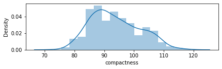

```
circularity is Symmetrically Skewed as Skewness = 0.265
```

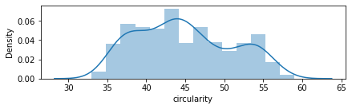

```
distance_circularity is Symmetrically Skewed as Skewness = 0.109
```

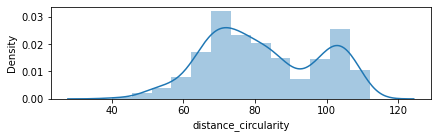

```
radius_ratio is Symmetrically Skewed as Skewness = 0.398
```

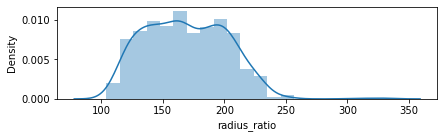

```
pr.axis_aspect_ratio is Positively Skewed towards Right side of asymmetric distribution as Skewness = 3.835
```

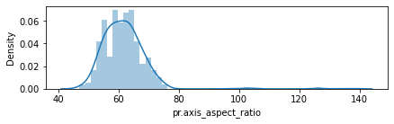

```
max.length_aspect_ratio is Positively Skewed towards Right side of asymmetric distribution as Skewness = 6.778
```

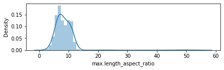

```
scatter_ratio is Positively Skewed towards Right side of asymmetric distribution as Skewness = 0.609
```

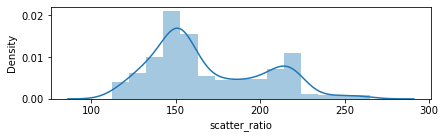

```
elongatedness is Symmetrically Skewed as Skewness = 0.047
```

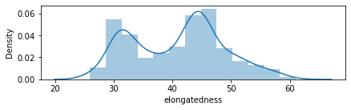

```
pr.axis_rectangularity is Positively Skewed towards Right side of asymmetric distribution as Skewness = 0.774
```

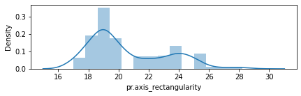

```
max.length_rectangularity is Symmetrically Skewed as Skewness = 0.256
```

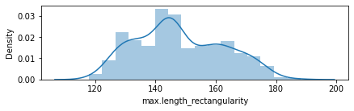

```
scaled_variance is Positively Skewed towards Right side of asymmetric distribution as Skewness = 0.656
```

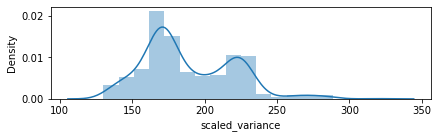

```
scaled_variance.1 is Positively Skewed towards Right side of asymmetric distribution as Skewness = 0.845
```

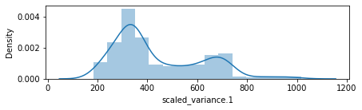

```
scaled_radius_of_gyration is Symmetrically Skewed as Skewness = 0.28
```

[6 more figures not shown]

```python
#Checking of skewness
n=1
for x in vc1:
    series          = vc1[x]
    skewness        = series.skew()
    if skewness > -.5  and skewness < .5 :
        print(x,"is Symmetrically Skewed as Skewness =",round(skewness,3),'\n')
    elif skewness > .25:
            print(x,"is Positively Skewed towards Right side of asymmetric distribution as Skewness =",round(skewness,3),'\n')
    elif skewness < -.25:
            print(x,"is Negatively Skewed towards Left side of asymmetric distribution as Skewness =",round(skewness,3),'\n')
    plt.figure(figsize= (15,20))
    plt.subplot(10,2,n)
    n=n+1
    sns.distplot(vc1[x])
    plt.xlabel(x)
    plt.show()
```

#### By seeing the graphs of columns having 'nan' values, the filling of 'nan' values has to be done in different ways

#### 5 point summary defiened given as follows:

> 1. The minimum.
> 2. Q1 (the first quartile, or the 25% mark).
> 3. The median (50%).
> 4. Q3 (the third quartile, or the 75% mark).
> 5. The maximum.

```python
vc.describe()
```

|  | compactness | circularity | distance_circularity | radius_ratio | pr.axis_aspect_ratio | max.length_aspect_ratio | scatter_ratio | elongatedness | pr.axis_rectangularity | max.length_rectangularity | scaled_variance | scaled_variance.1 | scaled_radius_of_gyration | scaled_radius_of_gyration.1 | skewness_about | skewness_about.1 | skewness_about.2 | hollows_ratio |
| --- | --- | --- | --- | --- | --- | --- | --- | --- | --- | --- | --- | --- | --- | --- | --- | --- | --- | --- |
| count | 846.000000 | 846.000000 | 846.000000 | 846.000000 | 846.000000 | 846.000000 | 846.000000 | 846.000000 | 846.000000 | 846.000000 | 846.000000 | 846.000000 | 846.000000 | 846.000000 | 846.000000 | 846.000000 | 846.000000 | 846.000000 |
| mean | 93.678487 | 44.823877 | 82.100473 | 168.874704 | 61.677305 | 8.567376 | 168.887707 | 40.936170 | 20.580378 | 147.998818 | 188.596927 | 439.314421 | 174.706856 | 72.443262 | 6.361702 | 12.600473 | 188.918440 | 195.632388 |
| std | 8.234474 | 6.134272 | 15.741569 | 33.401356 | 7.882188 | 4.601217 | 33.197710 | 7.811882 | 2.588558 | 14.515652 | 31.360427 | 176.496341 | 32.546277 | 7.468734 | 4.903244 | 8.930962 | 6.152247 | 7.438797 |
| min | 73.000000 | 33.000000 | 40.000000 | 104.000000 | 47.000000 | 2.000000 | 112.000000 | 26.000000 | 17.000000 | 118.000000 | 130.000000 | 184.000000 | 109.000000 | 59.000000 | 0.000000 | 0.000000 | 176.000000 | 181.000000 |
| 25% | 87.000000 | 40.000000 | 70.000000 | 141.000000 | 57.000000 | 7.000000 | 147.000000 | 33.000000 | 19.000000 | 137.000000 | 167.000000 | 318.250000 | 149.000000 | 67.000000 | 2.000000 | 5.000000 | 184.000000 | 190.250000 |
| 50% | 93.000000 | 44.000000 | 80.000000 | 167.000000 | 61.000000 | 8.000000 | 157.000000 | 43.000000 | 20.000000 | 146.000000 | 179.000000 | 363.500000 | 173.500000 | 71.500000 | 6.000000 | 11.000000 | 188.000000 | 197.000000 |
| 75% | 100.000000 | 49.000000 | 98.000000 | 195.000000 | 65.000000 | 10.000000 | 198.000000 | 46.000000 | 23.000000 | 159.000000 | 217.000000 | 586.750000 | 198.000000 | 75.000000 | 9.000000 | 19.000000 | 193.000000 | 201.000000 |
| max | 119.000000 | 59.000000 | 112.000000 | 333.000000 | 138.000000 | 55.000000 | 265.000000 | 61.000000 | 29.000000 | 188.000000 | 320.000000 | 1018.000000 | 268.000000 | 135.000000 | 22.000000 | 41.000000 | 206.000000 | 211.000000 |

```
No. of outlier of compactness in dataset is 1
Which are [119.0]
```

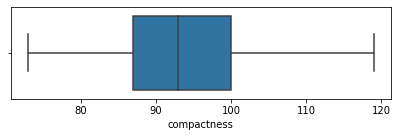

```
No. of outlier of circularity in dataset is 0
Which are []
```

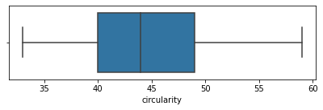

```
No. of outlier of distance_circularity in dataset is 0
Which are []
```

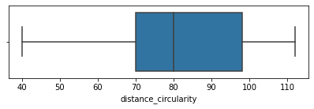

```
No. of outlier of radius_ratio in dataset is 3
Which are [306.0, 322.0, 333.0]
```

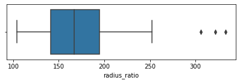

```
No. of outlier of pr.axis_aspect_ratio in dataset is 8
Which are [103.0, 126.0, 126.0, 133.0, 102.0, 138.0, 97.0, 105.0]
```

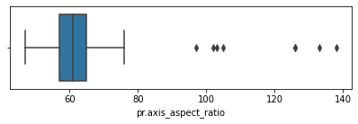

```
No. of outlier of max.length_aspect_ratio in dataset is 9
Which are [52.0, 49.0, 52.0, 48.0, 43.0, 49.0, 25.0, 46.0, 55.0]
```

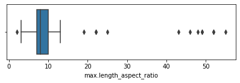

```
No. of outlier of scatter_ratio in dataset is 0
Which are []
```

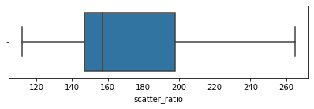

```
No. of outlier of elongatedness in dataset is 0
Which are []
```

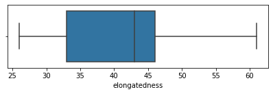

```
No. of outlier of pr.axis_rectangularity in dataset is 1
Which are [29.0]
```

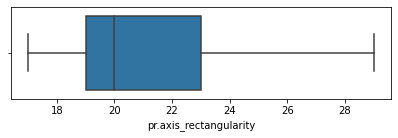

```
No. of outlier of max.length_rectangularity in dataset is 0
Which are []
```

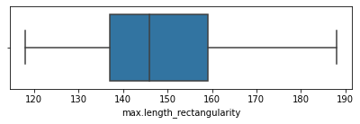

```
No. of outlier of scaled_variance in dataset is 6
Which are [288.0, 320.0, 285.0, 285.0, 287.0, 285.0]
```

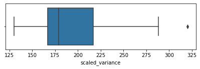

```
No. of outlier of scaled_variance.1 in dataset is 4
Which are [998.0, 982.0, 987.0, 1018.0]
```

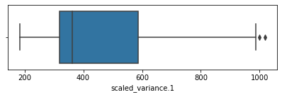

```
No. of outlier of scaled_radius_of_gyration in dataset is 0
Which are []
```

[6 more figures not shown]

```python
n=1
for x in vc1:
    vc1[x]=vc1[x].astype(float)
    att = vc1[x]
    mean = np.mean(att)
    std = np.std(att)
    outlier = []
    outliervalue = []
    for i in att:
        z = (i-mean)/std
        if z < -3.00 or z > 3.00:
            outlier.append(i)
            outliervalue.append(z)
    print('No. of outlier of',x,'in dataset is',len(outlier),'\nWhich are',outlier)
    plt.figure(figsize= (15,20))
    plt.subplot(10,2,n)
    n=n+1
    sns.boxplot(vc1[x])
    plt.xlabel(x)
    plt.show()
```

### Target column is *class* column

#### As target column is *object type*, to make it as *categorical column*, it needs be *lable encoding*

```python
#making column for label encoding
vc['eclass']=vc['class']
vc[['class','eclass']].head()
```

|  | class | eclass |
| --- | --- | --- |
| 1 | van | van |
| 2 | van | van |
| 3 | car | car |
| 4 | van | van |
| 5 | bus | bus |

```python
# label_encoding class column
label_encoder = preprocessing.LabelEncoder()
vc['eclass']= label_encoder.fit_transform(vc['eclass'])
vc[['class','eclass']].head()
```

|  | class | eclass |
| --- | --- | --- |
| 1 | van | 2 |
| 2 | van | 2 |
| 3 | car | 1 |
| 4 | van | 2 |
| 5 | bus | 0 |

```python
vc['eclass'].dtype
```

```
dtype('int64')
```

```python
vc['eclass']=vc['eclass'].add(1)
```

```python
vc['eclass'].unique()
vc[['class','eclass']].head()
```

|  | class | eclass |
| --- | --- | --- |
| 1 | van | 3 |
| 2 | van | 3 |
| 3 | car | 2 |
| 4 | van | 3 |
| 5 | bus | 1 |

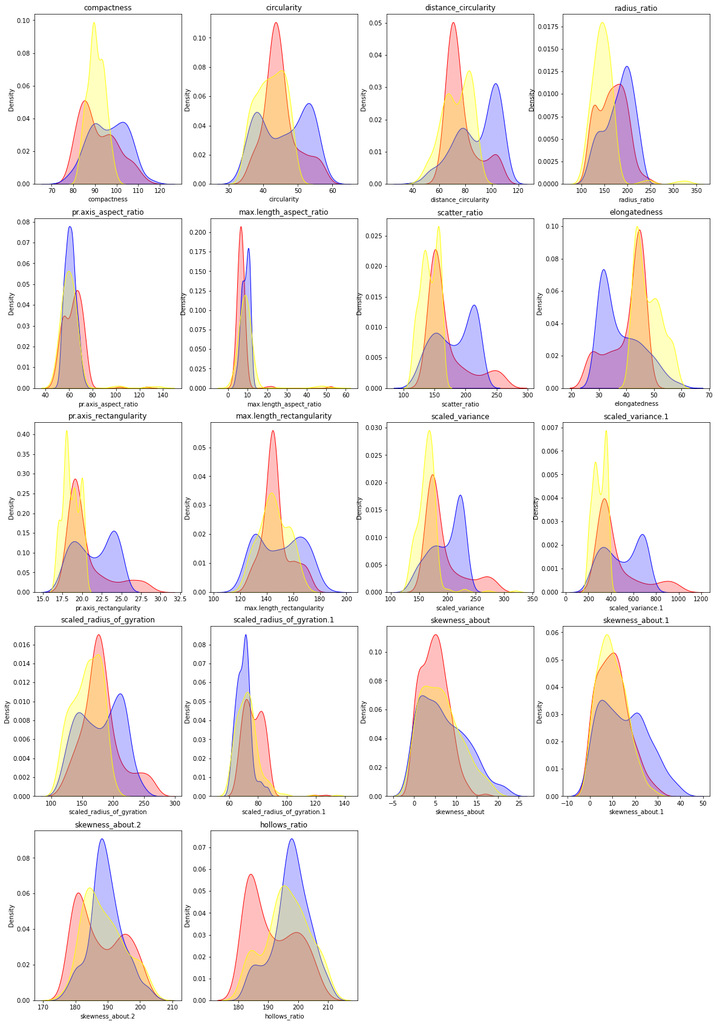

```python
# kde plots to show the distribution of the all the variables with respect to dependent variable
k=1
plt.figure(figsize=(20,30))
for col in vc.columns[0:18]:
    plt.subplot(5,4,k)
    sns.kdeplot(vc[vc['eclass']==1][col],color='red',label='car',shade=True)
    sns.kdeplot(vc[vc['eclass']==2][col],color='blue',label='bus',shade=True)
    sns.kdeplot(vc[vc['eclass']==3][col],color='yellow',label='van',shade=True)
    plt.title(col)
    k=k+1
```

```python
a = vc.corr()
a
```

|  | compactness | circularity | distance_circularity | radius_ratio | pr.axis_aspect_ratio | max.length_aspect_ratio | scatter_ratio | elongatedness | pr.axis_rectangularity | max.length_rectangularity | scaled_variance | scaled_variance.1 | scaled_radius_of_gyration | scaled_radius_of_gyration.1 | skewness_about | skewness_about.1 | skewness_about.2 | hollows_ratio | eclass |
| --- | --- | --- | --- | --- | --- | --- | --- | --- | --- | --- | --- | --- | --- | --- | --- | --- | --- | --- | --- |
| compactness | 1.000000 | 0.684887 | 0.789928 | 0.689743 | 0.091534 | 0.148249 | 0.812620 | -0.788750 | 0.813694 | 0.676143 | 0.762070 | 0.814012 | 0.585243 | -0.249593 | 0.236078 | 0.157015 | 0.298537 | 0.365552 | -0.033796 |
| circularity | 0.684887 | 1.000000 | 0.792320 | 0.620912 | 0.153778 | 0.251467 | 0.847938 | -0.821472 | 0.843400 | 0.961318 | 0.796306 | 0.835946 | 0.925816 | 0.051946 | 0.144198 | -0.011439 | -0.104426 | 0.046351 | -0.158910 |
| distance_circularity | 0.789928 | 0.792320 | 1.000000 | 0.767035 | 0.158456 | 0.264686 | 0.905076 | -0.911307 | 0.893025 | 0.774527 | 0.861519 | 0.886017 | 0.705771 | -0.225944 | 0.113924 | 0.265547 | 0.146098 | 0.332732 | -0.064467 |
| radius_ratio | 0.689743 | 0.620912 | 0.767035 | 1.000000 | 0.663447 | 0.450052 | 0.734429 | -0.789481 | 0.708385 | 0.568949 | 0.793415 | 0.718436 | 0.536372 | -0.180397 | 0.048713 | 0.173741 | 0.382214 | 0.471309 | -0.182186 |
| pr.axis_aspect_ratio | 0.091534 | 0.153778 | 0.158456 | 0.663447 | 1.000000 | 0.648724 | 0.103732 | -0.183035 | 0.079604 | 0.126909 | 0.272910 | 0.089189 | 0.121971 | 0.152950 | -0.058371 | -0.031976 | 0.239886 | 0.267725 | -0.098178 |
| max.length_aspect_ratio | 0.148249 | 0.251467 | 0.264686 | 0.450052 | 0.648724 | 1.000000 | 0.166191 | -0.180140 | 0.161502 | 0.305943 | 0.318957 | 0.143253 | 0.189743 | 0.295735 | 0.015599 | 0.043422 | -0.026081 | 0.143919 | 0.207619 |
| scatter_ratio | 0.812620 | 0.847938 | 0.905076 | 0.734429 | 0.103732 | 0.166191 | 1.000000 | -0.971601 | 0.989751 | 0.809083 | 0.948662 | 0.993012 | 0.799875 | -0.027542 | 0.074458 | 0.212428 | 0.005628 | 0.118817 | -0.288895 |
| elongatedness | -0.788750 | -0.821472 | -0.911307 | -0.789481 | -0.183035 | -0.180140 | -0.971601 | 1.000000 | -0.948996 | -0.775854 | -0.936382 | -0.953816 | -0.766314 | 0.103302 | -0.052600 | -0.185053 | -0.115126 | -0.216905 | 0.339344 |
| pr.axis_rectangularity | 0.813694 | 0.843400 | 0.893025 | 0.708385 | 0.079604 | 0.161502 | 0.989751 | -0.948996 | 1.000000 | 0.810934 | 0.934227 | 0.988213 | 0.796690 | -0.015495 | 0.083767 | 0.214700 | -0.018649 | 0.099286 | -0.258481 |
| max.length_rectangularity | 0.676143 | 0.961318 | 0.774527 | 0.568949 | 0.126909 | 0.305943 | 0.809083 | -0.775854 | 0.810934 | 1.000000 | 0.744985 | 0.794615 | 0.866450 | 0.041622 | 0.135852 | 0.001366 | -0.103948 | 0.076770 | -0.032399 |
| scaled_variance | 0.762070 | 0.796306 | 0.861519 | 0.793415 | 0.272910 | 0.318957 | 0.948662 | -0.936382 | 0.934227 | 0.744985 | 1.000000 | 0.945678 | 0.778917 | 0.113078 | 0.036729 | 0.194239 | 0.014219 | 0.085695 | -0.312943 |
| scaled_variance.1 | 0.814012 | 0.835946 | 0.886017 | 0.718436 | 0.089189 | 0.143253 | 0.993012 | -0.953816 | 0.988213 | 0.794615 | 0.945678 | 1.000000 | 0.795017 | -0.015401 | 0.076877 | 0.200811 | 0.006219 | 0.102935 | -0.288115 |
| scaled_radius_of_gyration | 0.585243 | 0.925816 | 0.705771 | 0.536372 | 0.121971 | 0.189743 | 0.799875 | -0.766314 | 0.796690 | 0.866450 | 0.778917 | 0.795017 | 1.000000 | 0.191473 | 0.166483 | -0.056153 | -0.224450 | -0.118002 | -0.250267 |
| scaled_radius_of_gyration.1 | -0.249593 | 0.051946 | -0.225944 | -0.180397 | 0.152950 | 0.295735 | -0.027542 | 0.103302 | -0.015495 | 0.041622 | 0.113078 | -0.015401 | 0.191473 | 1.000000 | -0.088355 | -0.126183 | -0.748865 | -0.802123 | -0.212601 |
| skewness_about | 0.236078 | 0.144198 | 0.113924 | 0.048713 | -0.058371 | 0.015599 | 0.074458 | -0.052600 | 0.083767 | 0.135852 | 0.036729 | 0.076877 | 0.166483 | -0.088355 | 1.000000 | -0.034990 | 0.115297 | 0.097126 | 0.119581 |
| skewness_about.1 | 0.157015 | -0.011439 | 0.265547 | 0.173741 | -0.031976 | 0.043422 | 0.212428 | -0.185053 | 0.214700 | 0.001366 | 0.194239 | 0.200811 | -0.056153 | -0.126183 | -0.034990 | 1.000000 | 0.077310 | 0.204990 | -0.010680 |
| skewness_about.2 | 0.298537 | -0.104426 | 0.146098 | 0.382214 | 0.239886 | -0.026081 | 0.005628 | -0.115126 | -0.018649 | -0.103948 | 0.014219 | 0.006219 | -0.224450 | -0.748865 | 0.115297 | 0.077310 | 1.000000 | 0.892581 | 0.067244 |
| hollows_ratio | 0.365552 | 0.046351 | 0.332732 | 0.471309 | 0.267725 | 0.143919 | 0.118817 | -0.216905 | 0.099286 | 0.076770 | 0.085695 | 0.102935 | -0.118002 | -0.802123 | 0.097126 | 0.204990 | 0.892581 | 1.000000 | 0.235874 |
| eclass | -0.033796 | -0.158910 | -0.064467 | -0.182186 | -0.098178 | 0.207619 | -0.288895 | 0.339344 | -0.258481 | -0.032399 | -0.312943 | -0.288115 | -0.250267 | -0.212601 | 0.119581 | -0.010680 | 0.067244 | 0.235874 | 1.000000 |

```python
a['eclass']
```

```
compactness                   -0.033796
circularity                   -0.158910
distance_circularity          -0.064467
radius_ratio                  -0.182186
pr.axis_aspect_ratio          -0.098178
max.length_aspect_ratio        0.207619
scatter_ratio                 -0.288895
elongatedness                  0.339344
pr.axis_rectangularity        -0.258481
max.length_rectangularity     -0.032399
scaled_variance               -0.312943
scaled_variance.1             -0.288115
scaled_radius_of_gyration     -0.250267
scaled_radius_of_gyration.1   -0.212601
skewness_about                 0.119581
skewness_about.1              -0.010680
skewness_about.2               0.067244
hollows_ratio                  0.235874
eclass                         1.000000
Name: eclass, dtype: float64
```

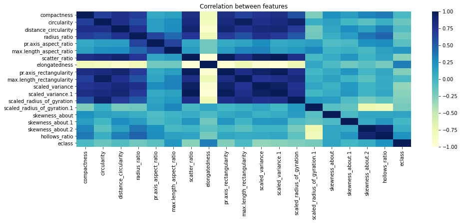

```python
plt.figure(figsize=(15,5))

sns.heatmap(a, cmap='YlGnBu', vmax=1.0, vmin=-1.0)

plt.title('Correlation between features')
plt.show()
```

```python
#sns.pairplot(vc,diag_kws=dict(fill=False))
```

```
Distribution of Target column
```

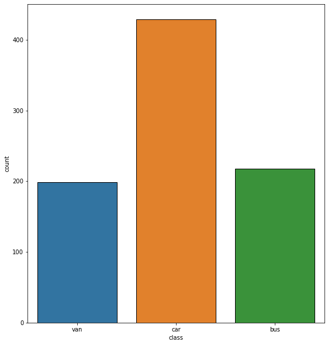

```python
#Get the target column distribution.
fig = plt.figure(figsize=(20,10))
fig_dims = (1, 2)

print('Distribution of Target column')
plt.subplot2grid(fig_dims, (0,0))
#vc['class'].value_counts().plot(kind='bar',',)
sns.countplot(x="class", data=vc,edgecolor=".001")
```

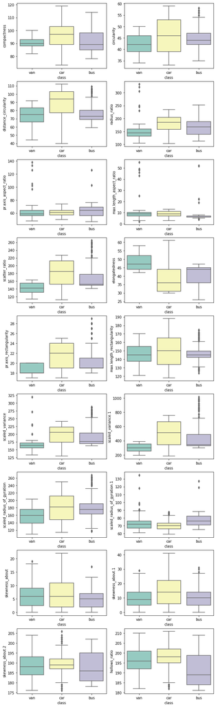

```python
#Getting the target column distributions
vc1=vc.drop(['eclass','class'],axis=1)
plt.figure(figsize= (10,40))
n=1
for i in vc1:
    vc1[i]=vc1[i].astype(float)
    att = vc1[i]
    plt.subplot(10,2,n)
    n=n+1
    sns.boxplot(x='class',y=i,data=vc,palette="Set3")
plt.show()
```

```python
vc1.shape
```

```
(846, 18)
```

## 3.1 Split the dataset into training and test set in the ratio of 70:30 (Training:Test)

### With random state = 202

```python
x=vc.drop(['eclass','class'],axis=1)
y=vc["eclass"]
accuracies={}
```

```python
XScaled=x.apply(zscore)
XScaled.head()
```

|  | compactness | circularity | distance_circularity | radius_ratio | pr.axis_aspect_ratio | max.length_aspect_ratio | scatter_ratio | elongatedness | pr.axis_rectangularity | max.length_rectangularity | scaled_variance | scaled_variance.1 | scaled_radius_of_gyration | scaled_radius_of_gyration.1 | skewness_about | skewness_about.1 | skewness_about.2 | hollows_ratio |
| --- | --- | --- | --- | --- | --- | --- | --- | --- | --- | --- | --- | --- | --- | --- | --- | --- | --- | --- |
| 1 | 0.160580 | 0.518073 | 0.057177 | 0.273363 | 1.310398 | 0.311542 | -0.207598 | 0.136262 | -0.224342 | 0.758332 | -0.401920 | -0.341934 | 0.285705 | -0.327326 | -0.073812 | 0.380870 | -0.312012 | 0.183957 |
| 2 | -0.325470 | -0.623732 | 0.120741 | -0.835032 | -0.593753 | 0.094079 | -0.599423 | 0.520519 | -0.610886 | -0.344578 | -0.593357 | -0.619724 | -0.513630 | -0.059384 | 0.538390 | 0.156798 | 0.013265 | 0.452977 |
| 3 | 1.254193 | 0.844303 | 1.519141 | 1.202018 | 0.548738 | 0.311542 | 1.148719 | -1.144597 | 0.935290 | 0.689401 | 1.097671 | 1.109379 | 1.392477 | 0.074587 | 1.558727 | -0.403383 | -0.149374 | 0.049447 |
| 4 | -0.082445 | -0.623732 | -0.006386 | -0.295813 | 0.167907 | 0.094079 | -0.750125 | 0.648605 | -0.610886 | -0.344578 | -0.912419 | -0.738777 | -1.466683 | -1.265121 | -0.073812 | -0.291347 | 1.639649 | 1.529056 |
| 5 | -1.054545 | -0.134387 | -0.769150 | 1.082192 | 5.245643 | 9.444962 | -0.599423 | 0.520519 | -0.610886 | -0.275646 | 1.671982 | -0.648070 | 0.408680 | 7.309005 | 0.538390 | -0.179311 | -1.450481 | -1.699181 |

```python
x_train, x_test, y_train,  y_test = train_test_split(x, y,train_size=0.7, test_size=0.3,random_state=202)
```

## 4.1 Using the Support Vector Machines

```python
from sklearn.svm import SVC

svm = SVC(random_state=42)
svm.fit(x_train, y_train)
svm.score(x_test, y_test)

y_pred = svm.predict(x_test)
```

```python
accuracy = metrics.accuracy_score(y_test, y_pred)
accuracies['SVM Raw'] = accuracy
print("Accuracy of Support vector machine:",accuracy)
```

```
Accuracy of Support vector machine: 0.6889763779527559
```

```python
accu = pd.DataFrame({'Model': ['SVM Raw'], 'Accuracy' : [accuracy]})
```

```python
print('Compute report precision    recall  F-measure  support\n',classification_report(y_test, y_pred,target_names=vc['class'].unique()))
```

[output not shown]

```python
vc[['class','eclass']]
```

|  | class | eclass |
| --- | --- | --- |
| 1 | van | 3 |
| 2 | van | 3 |
| 3 | car | 2 |
| 4 | van | 3 |
| 5 | bus | 1 |
| ... | ... | ... |
| 842 | car | 2 |
| 843 | van | 3 |
| 844 | car | 2 |
| 845 | car | 2 |
| 846 | van | 3 |

846 rows × 2 columns

```python
print('Confusion Matrix: ')
print(metrics.confusion_matrix(y_test, y_pred))
```

```
Confusion Matrix:
[[35 25  5]
 [ 6 99 26]
 [17  0 41]]
```

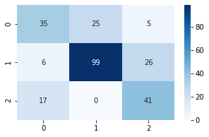

```python
cm = confusion_matrix(y_test, y_pred)
plt.figure(figsize = (5,3))
sns.heatmap(cm, annot=True,cmap='Blues', fmt='g')
```

# Performing K-fold cross validation

```python
# number of splits (25)
kfold = KFold(n_splits = 25, random_state = 56)

svm = SVC()
scores = cross_val_score(svm, XScaled, y, cv = kfold)
accuracies['SVM KFold'] = scores.mean()
print('Overall Accuracy : {:.2f}% ({:.2f}%)'.format(scores.mean(), scores.std()))
```

```
Overall Accuracy : 0.97% (0.02%)
```

```python
accu1 = pd.DataFrame({'Model': ['SVM( Kfold )'], 'Accuracy' : [scores.mean()]})
accu = pd.concat([accu,accu1]).drop_duplicates()
accu
```

|  | Model | Accuracy |
| --- | --- | --- |
| 0 | SVM Raw | 0.688976 |
| 0 | SVM( Kfold ) | 0.965704 |

```python
accuracies
```

```
{'SVM Raw': 0.6889763779527559, 'SVM KFold': 0.9657040998217468}
```

# Extracting Principal Components that capture about 95% of the variance of the data

## Implementation of the PCA with step by step

### 1. Normalize / Scale the data

```python
x=vc.drop(['eclass','class'],axis=1)
y=vc["eclass"]
```

```python
x_train,x_test,y_train,y_test = train_test_split(x,y,train_size=0.7,test_size=0.3,random_state=202)
```

```python
XScaled=x.apply(zscore)
XScaled.head()
```

|  | compactness | circularity | distance_circularity | radius_ratio | pr.axis_aspect_ratio | max.length_aspect_ratio | scatter_ratio | elongatedness | pr.axis_rectangularity | max.length_rectangularity | scaled_variance | scaled_variance.1 | scaled_radius_of_gyration | scaled_radius_of_gyration.1 | skewness_about | skewness_about.1 | skewness_about.2 | hollows_ratio |
| --- | --- | --- | --- | --- | --- | --- | --- | --- | --- | --- | --- | --- | --- | --- | --- | --- | --- | --- |
| 1 | 0.160580 | 0.518073 | 0.057177 | 0.273363 | 1.310398 | 0.311542 | -0.207598 | 0.136262 | -0.224342 | 0.758332 | -0.401920 | -0.341934 | 0.285705 | -0.327326 | -0.073812 | 0.380870 | -0.312012 | 0.183957 |
| 2 | -0.325470 | -0.623732 | 0.120741 | -0.835032 | -0.593753 | 0.094079 | -0.599423 | 0.520519 | -0.610886 | -0.344578 | -0.593357 | -0.619724 | -0.513630 | -0.059384 | 0.538390 | 0.156798 | 0.013265 | 0.452977 |
| 3 | 1.254193 | 0.844303 | 1.519141 | 1.202018 | 0.548738 | 0.311542 | 1.148719 | -1.144597 | 0.935290 | 0.689401 | 1.097671 | 1.109379 | 1.392477 | 0.074587 | 1.558727 | -0.403383 | -0.149374 | 0.049447 |
| 4 | -0.082445 | -0.623732 | -0.006386 | -0.295813 | 0.167907 | 0.094079 | -0.750125 | 0.648605 | -0.610886 | -0.344578 | -0.912419 | -0.738777 | -1.466683 | -1.265121 | -0.073812 | -0.291347 | 1.639649 | 1.529056 |
| 5 | -1.054545 | -0.134387 | -0.769150 | 1.082192 | 5.245643 | 9.444962 | -0.599423 | 0.520519 | -0.610886 | -0.275646 | 1.671982 | -0.648070 | 0.408680 | 7.309005 | 0.538390 | -0.179311 | -1.450481 | -1.699181 |

### 2.Generate the covariance matrix / correlation matrix for all the dimensions

#### Covariance is the direction of the linear relationship between variables.

```python
covMatrix = np.cov(XScaled,rowvar=False)
pd.DataFrame(covMatrix)
```

|  | 0 | 1 | 2 | 3 | 4 | 5 | 6 | 7 | 8 | 9 | 10 | 11 | 12 | 13 | 14 | 15 | 16 | 17 |
| --- | --- | --- | --- | --- | --- | --- | --- | --- | --- | --- | --- | --- | --- | --- | --- | --- | --- | --- |
| 0 | 1.001183 | 0.685698 | 0.790863 | 0.690560 | 0.091643 | 0.148425 | 0.813582 | -0.789683 | 0.814657 | 0.676943 | 0.762972 | 0.814976 | 0.585935 | -0.249888 | 0.236358 | 0.157200 | 0.298890 | 0.365984 |
| 1 | 0.685698 | 1.001183 | 0.793258 | 0.621647 | 0.153960 | 0.251764 | 0.848941 | -0.822444 | 0.844398 | 0.962456 | 0.797248 | 0.836935 | 0.926912 | 0.052008 | 0.144368 | -0.011452 | -0.104550 | 0.046406 |
| 2 | 0.790863 | 0.793258 | 1.001183 | 0.767942 | 0.158643 | 0.265000 | 0.906147 | -0.912385 | 0.894082 | 0.775444 | 0.862539 | 0.887066 | 0.706607 | -0.226211 | 0.114059 | 0.265861 | 0.146271 | 0.333126 |
| 3 | 0.690560 | 0.621647 | 0.767942 | 1.001183 | 0.664232 | 0.450584 | 0.735298 | -0.790416 | 0.709224 | 0.569623 | 0.794354 | 0.719286 | 0.537007 | -0.180611 | 0.048770 | 0.173946 | 0.382666 | 0.471867 |
| 4 | 0.091643 | 0.153960 | 0.158643 | 0.664232 | 1.001183 | 0.649491 | 0.103855 | -0.183252 | 0.079698 | 0.127059 | 0.273233 | 0.089294 | 0.122115 | 0.153131 | -0.058440 | -0.032014 | 0.240170 | 0.268042 |
| 5 | 0.148425 | 0.251764 | 0.265000 | 0.450584 | 0.649491 | 1.001183 | 0.166388 | -0.180353 | 0.161693 | 0.306305 | 0.319334 | 0.143423 | 0.189967 | 0.296085 | 0.015618 | 0.043473 | -0.026111 | 0.144089 |
| 6 | 0.813582 | 0.848941 | 0.906147 | 0.735298 | 0.103855 | 0.166388 | 1.001183 | -0.972751 | 0.990922 | 0.810041 | 0.949785 | 0.994187 | 0.800821 | -0.027574 | 0.074546 | 0.212680 | 0.005634 | 0.118958 |
| 7 | -0.789683 | -0.822444 | -0.912385 | -0.790416 | -0.183252 | -0.180353 | -0.972751 | 1.001183 | -0.950119 | -0.776772 | -0.937490 | -0.954945 | -0.767221 | 0.103424 | -0.052662 | -0.185272 | -0.115262 | -0.217161 |
| 8 | 0.814657 | 0.844398 | 0.894082 | 0.709224 | 0.079698 | 0.161693 | 0.990922 | -0.950119 | 1.001183 | 0.811893 | 0.935333 | 0.989383 | 0.797632 | -0.015514 | 0.083866 | 0.214955 | -0.018671 | 0.099404 |
| 9 | 0.676943 | 0.962456 | 0.775444 | 0.569623 | 0.127059 | 0.306305 | 0.810041 | -0.776772 | 0.811893 | 1.001183 | 0.745866 | 0.795555 | 0.867476 | 0.041671 | 0.136012 | 0.001367 | -0.104071 | 0.076860 |
| 10 | 0.762972 | 0.797248 | 0.862539 | 0.794354 | 0.273233 | 0.319334 | 0.949785 | -0.937490 | 0.935333 | 0.745866 | 1.001183 | 0.946797 | 0.779838 | 0.113212 | 0.036772 | 0.194468 | 0.014236 | 0.085797 |
| 11 | 0.814976 | 0.836935 | 0.887066 | 0.719286 | 0.089294 | 0.143423 | 0.994187 | -0.954945 | 0.989383 | 0.795555 | 0.946797 | 1.001183 | 0.795958 | -0.015419 | 0.076968 | 0.201048 | 0.006226 | 0.103057 |
| 12 | 0.585935 | 0.926912 | 0.706607 | 0.537007 | 0.122115 | 0.189967 | 0.800821 | -0.767221 | 0.797632 | 0.867476 | 0.779838 | 0.795958 | 1.001183 | 0.191699 | 0.166680 | -0.056220 | -0.224716 | -0.118141 |
| 13 | -0.249888 | 0.052008 | -0.226211 | -0.180611 | 0.153131 | 0.296085 | -0.027574 | 0.103424 | -0.015514 | 0.041671 | 0.113212 | -0.015419 | 0.191699 | 1.001183 | -0.088460 | -0.126332 | -0.749751 | -0.803072 |
| 14 | 0.236358 | 0.144368 | 0.114059 | 0.048770 | -0.058440 | 0.015618 | 0.074546 | -0.052662 | 0.083866 | 0.136012 | 0.036772 | 0.076968 | 0.166680 | -0.088460 | 1.001183 | -0.035032 | 0.115434 | 0.097241 |
| 15 | 0.157200 | -0.011452 | 0.265861 | 0.173946 | -0.032014 | 0.043473 | 0.212680 | -0.185272 | 0.214955 | 0.001367 | 0.194468 | 0.201048 | -0.056220 | -0.126332 | -0.035032 | 1.001183 | 0.077402 | 0.205233 |
| 16 | 0.298890 | -0.104550 | 0.146271 | 0.382666 | 0.240170 | -0.026111 | 0.005634 | -0.115262 | -0.018671 | -0.104071 | 0.014236 | 0.006226 | -0.224716 | -0.749751 | 0.115434 | 0.077402 | 1.001183 | 0.893638 |
| 17 | 0.365984 | 0.046406 | 0.333126 | 0.471867 | 0.268042 | 0.144089 | 0.118958 | -0.217161 | 0.099404 | 0.076860 | 0.085797 | 0.103057 | -0.118141 | -0.803072 | 0.097241 | 0.205233 | 0.893638 | 1.001183 |

### 3. Performing eigen decomposition

#### To compute eigen vectors (which are the principal components) and the corresponding eigen values (which are the magnitudes of variance captured)

```python
pca = PCA()
pca.fit(XScaled)
```

```
PCA()
```

```python
#Eigen Values
print(pca.explained_variance_)
```

```
[9.40460261e+00 3.01492206e+00 1.90352502e+00 1.17993747e+00
 9.17260633e-01 5.39992629e-01 3.58870118e-01 2.21932456e-01
 1.60608597e-01 9.18572234e-02 6.64994118e-02 4.66005994e-02
 3.57947189e-02 2.74120657e-02 2.05792871e-02 1.79166314e-02
 1.00257898e-02 2.96445743e-03]
```

```python
#Eigen Vectors
print(pca.components_)
```

```
[[ 2.75283688e-01  2.93258469e-01  3.04609128e-01  2.67606877e-01
   8.05039890e-02  9.72756855e-02  3.17092750e-01 -3.14133155e-01
   3.13959064e-01  2.82830900e-01  3.09280359e-01  3.13788457e-01
   2.72047492e-01 -2.08137692e-02  4.14555082e-02  5.82250207e-02
   3.02795063e-02  7.41453913e-02]
 [-1.26953763e-01  1.25576727e-01 -7.29516436e-02 -1.89634378e-01
  -1.22174860e-01  1.07482875e-02  4.81181371e-02  1.27498515e-02
   5.99352482e-02  1.16220532e-01  6.22806229e-02  5.37843596e-02
   2.09233172e-01  4.88525148e-01 -5.50899716e-02 -1.24085090e-01
  -5.40914775e-01 -5.40354258e-01]
 [-1.19922479e-01 -2.48205467e-02 -5.60143254e-02  2.75074211e-01
   6.42012966e-01  5.91801304e-01 -9.76283108e-02  5.76484384e-02
  -1.09512416e-01 -1.70641987e-02  5.63239801e-02 -1.08840729e-01
  -3.14636493e-02  2.86277015e-01 -1.15679354e-01 -7.52828901e-02
   8.73592034e-03  3.95242743e-02]
 [ 7.83843562e-02  1.87337408e-01 -7.12008427e-02 -4.26053415e-02
   3.27257119e-02  3.14147277e-02 -9.57485748e-02  8.22901952e-02
  -9.24582989e-02  1.88005612e-01 -1.19844008e-01 -9.17449325e-02
   2.00095228e-01 -6.55051354e-02  6.04794251e-01 -6.66114117e-01
   1.05526253e-01  4.74890311e-02]
 [ 6.95178336e-02 -8.50649539e-02  4.06645651e-02 -4.61473714e-02
  -4.05494487e-02  2.13432566e-01 -1.54853055e-02  7.68518712e-02
   2.17633157e-03 -6.06366845e-02 -4.56472367e-04 -1.95548315e-02
  -6.15991681e-02  1.45530146e-01  7.29189842e-01  5.99196401e-01
  -1.00602332e-01 -2.98614819e-02]
 [ 1.44875476e-01 -3.02731148e-01 -1.38405773e-01  2.48136636e-01
   2.36932611e-01 -4.19330747e-01  1.16100153e-01 -1.41840112e-01
   9.80561329e-02 -4.61674972e-01  2.36225434e-01  1.57820194e-01
  -1.35576278e-01  2.41356821e-01  2.03209257e-01 -1.91960802e-01
   1.56939174e-01 -2.41222817e-01]
 [ 4.51862331e-01 -2.49103387e-01  7.40350569e-02 -1.76912814e-01
  -3.97876601e-01  5.03413610e-01  6.49879382e-02  1.38112945e-02
   9.66573058e-02 -1.04552173e-01  1.14622578e-01  8.37350220e-02
  -3.73944382e-01  1.11952983e-01 -8.06328902e-02 -2.84558723e-01
   1.81451818e-02  1.57237839e-02]
 [-5.66136785e-01 -1.79851809e-01  4.34748988e-01  1.01998360e-01
  -6.87147927e-02  1.61153097e-01  1.00688056e-01 -2.15497166e-01
   6.35933915e-02 -2.49495867e-01  5.02096319e-02  4.37649907e-02
  -1.08474496e-01 -3.40878491e-01  1.56487670e-01 -2.08774083e-01
  -3.04580219e-01 -3.04186304e-02]
```

[output cut: 35 more lines]

```
 [-6.50956666e-02 -2.61244802e-01  7.82651714e-02  5.60792139e-01
  -3.22276873e-01  4.87809642e-02  1.81839668e-02 -2.50330194e-02
   1.64490784e-01  1.47280090e-01 -5.64444637e-01 -6.85856929e-02
   1.47099233e-01  2.32941262e-01 -2.77589170e-02  2.78187408e-03
   1.90629960e-01 -1.20966490e-01]
 [ 6.00532537e-03 -7.38059396e-02  2.50791236e-02  3.59880417e-02
  -1.25847434e-02  2.84168792e-02  2.49652703e-01  4.21478467e-02
  -7.17396292e-01  4.70233017e-02 -1.71503771e-01  6.16589383e-01
   2.64910290e-02  1.42959461e-02 -1.74310271e-03  7.08894692e-03
  -7.67874680e-03 -6.37681817e-03]
 [-1.00728764e-02 -9.15939674e-03  6.94599696e-03 -4.20156482e-02
   3.12698087e-02 -9.99915816e-03  8.40975659e-01  2.38188639e-01
  -1.01154594e-01 -1.69481636e-02  6.04665108e-03 -4.69202757e-01
   1.17483082e-02  3.14812146e-03 -3.03156233e-03 -1.25315953e-02
   4.34282436e-02 -6.47700819e-03]]
```

**Getting the percentage of variance explained by each principle component from 1 to 18 (as there are 18 independent columns in dataset)**

```python
k = 1
total = []
for i in pca.explained_variance_ratio_*100:
    print('Variance explained by Principle Component',k,'is : {:.2f}%'.format(i))
    k+=1
    total.append(i)
print('\nTotal variance explained by all the principle components:',sum(total),'%')
```

```
Variance explained by Principle Component 1 is : 52.19%
Variance explained by Principle Component 2 is : 16.73%
Variance explained by Principle Component 3 is : 10.56%
Variance explained by Principle Component 4 is : 6.55%
Variance explained by Principle Component 5 is : 5.09%
Variance explained by Principle Component 6 is : 3.00%
Variance explained by Principle Component 7 is : 1.99%
Variance explained by Principle Component 8 is : 1.23%
Variance explained by Principle Component 9 is : 0.89%
Variance explained by Principle Component 10 is : 0.51%
Variance explained by Principle Component 11 is : 0.37%
Variance explained by Principle Component 12 is : 0.26%
Variance explained by Principle Component 13 is : 0.20%
Variance explained by Principle Component 14 is : 0.15%
Variance explained by Principle Component 15 is : 0.11%
Variance explained by Principle Component 16 is : 0.10%
Variance explained by Principle Component 17 is : 0.06%
Variance explained by Principle Component 18 is : 0.02%

Total variance explained by all the principle components: 100.0 %
```

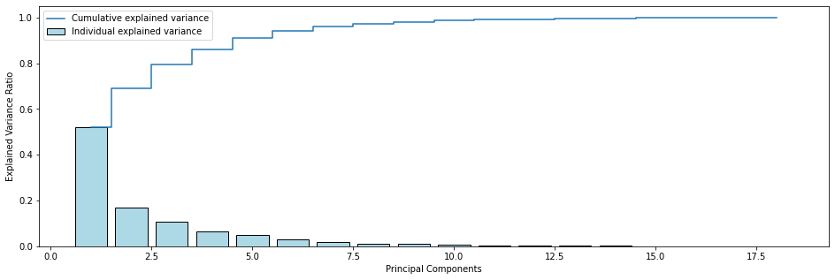

```python
# Implementing scree plot
plt.figure(figsize=(16 , 5))
plt.bar(range(1, 19), pca.explained_variance_ratio_, label = 'Individual explained variance',color='lightblue',edgecolor='black')
plt.step(range(1, 19), np.cumsum(pca.explained_variance_ratio_),where='mid', label = 'Cumulative explained variance')
plt.ylabel('Explained Variance Ratio')
plt.xlabel('Principal Components')
plt.legend(loc = 'best')
plt.show()
```

**Observation:- There is a steep drop in variance explained with increase in number of PC's. We will proceed with 7 variables/PC's we can explain over 95% of the variation in the original data**

```python
# NOTE - we are generating only 7 PCA dimensions (dimensionality reduction from 18 to 7)

pca2 = PCA(n_components=7)  # here you can notice we are specifying 7 PC components in the parameter called n_components
pca2.fit(XScaled)
```

```
PCA(n_components=7)
```

```python
pd.DataFrame(pca2.components_)
```

|  | 0 | 1 | 2 | 3 | 4 | 5 | 6 | 7 | 8 | 9 | 10 | 11 | 12 | 13 | 14 | 15 | 16 | 17 |
| --- | --- | --- | --- | --- | --- | --- | --- | --- | --- | --- | --- | --- | --- | --- | --- | --- | --- | --- |
| 0 | 0.275284 | 0.293258 | 0.304609 | 0.267607 | 0.080504 | 0.097276 | 0.317093 | -0.314133 | 0.313959 | 0.282831 | 0.309280 | 0.313788 | 0.272047 | -0.020814 | 0.041456 | 0.058225 | 0.030280 | 0.074145 |
| 1 | -0.126954 | 0.125577 | -0.072952 | -0.189634 | -0.122175 | 0.010748 | 0.048118 | 0.012750 | 0.059935 | 0.116221 | 0.062281 | 0.053784 | 0.209233 | 0.488525 | -0.055090 | -0.124085 | -0.540915 | -0.540354 |
| 2 | -0.119922 | -0.024821 | -0.056014 | 0.275074 | 0.642013 | 0.591801 | -0.097628 | 0.057648 | -0.109512 | -0.017064 | 0.056324 | -0.108841 | -0.031464 | 0.286277 | -0.115679 | -0.075283 | 0.008736 | 0.039524 |
| 3 | 0.078384 | 0.187337 | -0.071201 | -0.042605 | 0.032726 | 0.031415 | -0.095749 | 0.082290 | -0.092458 | 0.188006 | -0.119844 | -0.091745 | 0.200095 | -0.065505 | 0.604794 | -0.666114 | 0.105526 | 0.047489 |
| 4 | 0.069518 | -0.085065 | 0.040665 | -0.046147 | -0.040549 | 0.213433 | -0.015485 | 0.076852 | 0.002176 | -0.060637 | -0.000456 | -0.019555 | -0.061599 | 0.145530 | 0.729190 | 0.599196 | -0.100602 | -0.029861 |
| 5 | 0.144875 | -0.302731 | -0.138406 | 0.248137 | 0.236933 | -0.419331 | 0.116100 | -0.141840 | 0.098056 | -0.461675 | 0.236225 | 0.157820 | -0.135576 | 0.241357 | 0.203209 | -0.191961 | 0.156939 | -0.241223 |
| 6 | 0.451862 | -0.249103 | 0.074035 | -0.176913 | -0.397877 | 0.503414 | 0.064988 | 0.013811 | 0.096657 | -0.104552 | 0.114623 | 0.083735 | -0.373944 | 0.111953 | -0.080633 | -0.284559 | 0.018145 | 0.015724 |

```python
# Eigen Values (only 7)
pca2.explained_variance_
```

```
array([9.40460261, 3.01492206, 1.90352502, 1.17993747, 0.91726063,
       0.53999263, 0.35887012])
```

```python
sum(pca2.explained_variance_ratio_*100)
```

```
96.10354875345348
```

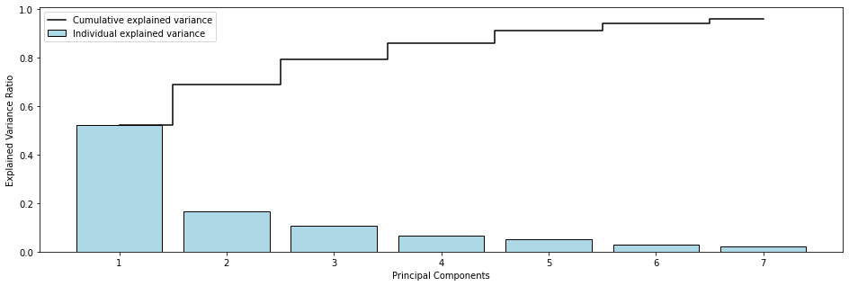

```python
plt.figure(figsize=(16 , 5))
plt.bar(range(1, 8), pca2.explained_variance_ratio_, label = 'Individual explained variance',color='lightblue',edgecolor='black')
plt.step(range(1, 8), np.cumsum(pca2.explained_variance_ratio_),where='mid', label = 'Cumulative explained variance',color = 'black')
plt.ylabel('Explained Variance Ratio')  # x axis label
plt.xlabel('Principal Components')      # y axis label
plt.legend()
```

```python
pca_transformed =  pca2.transform(XScaled)
```

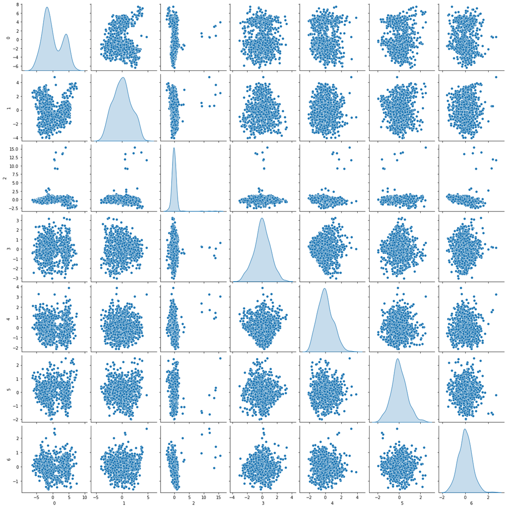

```python
sns.pairplot(pd.DataFrame(pca_transformed),diag_kind = 'kde')
```

**There is no Collinearity between the variables, hence correlation is close to zero. So we could able to decrease the correlation between independent variable.**

```python
print('original data shape')
print('shape of x_train',x_train.shape)
print('shape of y_train',y_train.shape)
print('shape of x_test',x_test.shape)
print('shape of y_test',y_test.shape)
```

```
original data shape
shape of x_train (592, 18)
shape of y_train (592,)
shape of x_test (254, 18)
shape of y_test (254,)
```

# Using SVM with Principal Components instead of the original data

```python
pca_x_train, pca_x_test, pca_y_train, pca_y_test = train_test_split(pca_transformed, y, test_size = 0.3, random_state = 202)


print('   shape of pca_x_train:',pca_x_train.shape)
print('   shape of pca_x_test:',pca_x_test.shape)
```

```
   shape of pca_x_train: (592, 7)
   shape of pca_x_test: (254, 7)
```

**Dimensions are reduced to 7, this is called the dimensionality reduction technique.**

```python
# creating a dataframe with the new dataset
pca_transformed = pd.DataFrame(pca_transformed,columns = vc.columns[0:7])
print(pca_transformed.shape)
```

```
(846, 7)
```

```python
svm_pca = SVC(random_state=42)
svm_pca.fit(pca_x_train, pca_y_train)
```

```
SVC(random_state=42)
```

```python
pca_accuracy = svm_pca.score(pca_x_test,pca_y_test)
accuracies['SVM PCA'] = pca_accuracy
print('Accuracy score of SVM model after reducing dimensions :',pca_accuracy)
```

```
Accuracy score of SVM model after reducing dimensions : 0.9015748031496063
```

```python
accu2 = pd.DataFrame({'Model': ['SVM( PCA )'], 'Accuracy' : pca_accuracy})
accu = pd.concat([accu,accu2]).drop_duplicates()
accu
```

|  | Model | Accuracy |
| --- | --- | --- |
| 0 | SVM Raw | 0.688976 |
| 0 | SVM( Kfold ) | 0.965704 |
| 0 | SVM( PCA ) | 0.901575 |

```python
svm_pca_pred = svm_pca.predict(pca_x_test)
```

```python
# generating classification report of actual and predicted values
print(metrics.classification_report(pca_y_test, svm_pca_pred))
```

```
              precision    recall  f1-score   support

           1       0.91      0.82      0.86        65
           2       0.92      0.93      0.92       131
           3       0.86      0.93      0.89        58

    accuracy                           0.90       254
   macro avg       0.90      0.89      0.89       254
weighted avg       0.90      0.90      0.90       254
```

```python
# confusion matrix of actual and predicted values
print('\n Confusion matrix:\n',metrics.confusion_matrix(pca_y_test, svm_pca_pred))
```

```
 Confusion matrix:
 [[ 53   8   4]
 [  4 122   5]
 [  1   3  54]]
```

# Performing K-fold cross validation with PCA

```python
kfold = KFold(n_splits = 25, random_state = 56)

# specifying the model to perform cross validation
model = SVC()

# noting accuracy scores of all the 25 split runs
scores = cross_val_score(model, pca_transformed, y, cv = kfold)
accuracies['SVM KFold-PCA'] = scores.mean()
# here we are getting average accuracy with standard deviation for range estimate
print('Overall Accuracy : {:.2f}% ({:.2f}%)'.format(scores.mean()*100.0, scores.std()*100.0))
```

```
Overall Accuracy : 92.43% (4.28%)
```

```python
accu3 = pd.DataFrame({'Model': ['SVM( KFlod-PCA )'], 'Accuracy' : scores.mean()})
accu = pd.concat([accu,accu3]).drop_duplicates()
accu
```

|  | Model | Accuracy |
| --- | --- | --- |
| 0 | SVM Raw | 0.688976 |
| 0 | SVM( Kfold ) | 0.965704 |
| 0 | SVM( PCA ) | 0.901575 |
| 0 | SVM( KFlod-PCA ) | 0.924278 |

```python
accuracies
```

```
{'SVM Raw': 0.6889763779527559,
 'SVM KFold': 0.9657040998217468,
 'SVM PCA': 0.9015748031496063,
 'SVM KFold-PCA': 0.9242780748663102}
```

# Comparing the accuracy scores of followings

1. Support vector machines – with raw data
2. Cross validation of Support vector machines – with raw data
3. Support vector machines – with Principal Components
4. Cross validation of Support vector machines – with Principal Components

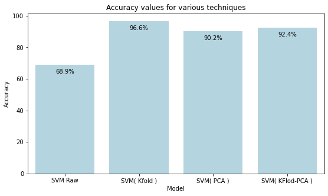

```python
fig = plt.figure(figsize=(9,5))
plt.title('Accuracy values for various techniques')

ax = sns.barplot(accu['Model'],accu['Accuracy']*100,color='lightblue');

for p in ax.patches:
    ax.annotate('{:.1f}%'.format(p.get_height()),
                    (p.get_x() + p.get_width() / 2, p.get_height()),
                    ha = 'center', va = 'center',
                    xytext = (0, -12),
                    textcoords = 'offset points')
```

**From the above bar plot, below interpretation were drawn:**

The cross validation seems performing well with the raw data with 96%(approx) but note that pca 90% accuracy is with only 7 dimensions where as rawdata has 18 dimensions.

But every thing has two sides, disadvantage of PCA is that *it cannot do interpretation with the model much, it's blackbox.*